# DATA 612 Project 1 - Global Baseline Predictors and RMSE

# Instruction

In this first assignment, we will attempt to predict ratings with very little information. We will first look at just raw averages across all (training dataset) users. We will then account for “bias” by normalizing across users and across items. We will work with ratings in a user-item matrix, where each rating may be (1) assigned to a training dataset, (2) assigned to a test dataset, or (3) missing.

# Introduction

In this project, a simple recommender system of McDonald’s Combo Meals is created. This system recommends McDonald’s Combo Meals to readers/customers who may then be interested to try out other Combo Meals than their usual calls. The data (ratings of Combo Meals) used in this project is collected by the three group members from themselves and their friends. The dataset contains a total of 10 users (customers) and their ratings of 11 items (McDonald’s Combo Meals).

# Load Packages

```r
library(rmdformats)
library(tidyverse)
library(knitr)
library(kableExtra)
library(formattable)
library(caTools)
library(yardstick)
library(gplots)
```

# Read Data

```r
data <- read_csv('https://raw.githubusercontent.com/oggyluky11/DATA-612-2020-SUMMER/master/Project%201/McDonald%20Meal%20Friend%20Rating.csv')

data
```

| Customer | Combo Meal | Rating |
| --- | --- | --- |
| Ricki | Big Mac | 3 |
| Ricki | Cheese burger | 1 |
| Ricki | Quarter Pounder w Cheese | 3 |
| Ricki | 10 Piece Chicken McNuggets | 4 |
| Ricki | Filet-O-Fish | 5 |
| Ricki | Artisan Grilled Chicken Sandwich | 4 |
| Ricki | Buttermilk Crispy Chicken Sandwich | 2 |
| Ricki | Bacon, Egg & Cheese Biscuit | 2 |
| Shirley | Big Mac | 2 |
| Shirley | Cheese burger | 3 |

[output cut: 77 more lines]

# Data Exploration

The data is in long format. From the summary below, we can see that not all customers(/users) have rated all 11 products(/items). Only Friend 1 has rated all 11 products.

After reshapping the data into a user-item matrix, it is observed that there are 23 missing values within all user-item combinations. The data is not very sparse according to the heatmap shown below.

Before reshaping:

```r
data %>%
  mutate_if(is.character,as.factor) %>%
  summary(maxsum = 20)
```

```
##      Customer                               Combo Meal     Rating
##  Frank   : 8   10 Piece Chicken McNuggets        : 8   Min.   :1.000
##  Friend 1:11   Artisan Grilled Chicken Sandwich  : 9   1st Qu.:2.000
##  Friend 2:10   Bacon, Egg & Cheese Biscuit       : 7   Median :3.000
##  Friend 3: 8   Big Mac                           :10   Mean   :2.816
##  Friend 4: 8   Buttermilk Crispy Chicken Sandwich: 7   3rd Qu.:4.000
##  Friend 5:10   Cheese burger                     : 7   Max.   :5.000
##  Friend 6: 7   Double Quarter Pounder w Cheese   : 7
##  Friend 7: 9   Egg McMuffin                      : 7
##  Ricki   : 8   Filet-O-Fish                      : 9
##  Shirley : 8   Quarter Pounder w Cheese          : 8
##                Sausage McMuffin w Egg            : 8
```

After reshaping:

```r
data %>%
  spread(key = `Combo Meal`, value = Rating) %>%
  gather(key = `Combo Meal`, value = Rating, - Customer) %>%
  mutate_if(is.character,as.factor) %>%
  summary(maxsum = 20)
```

```
##      Customer                               Combo Meal     Rating
##  Frank   :11   10 Piece Chicken McNuggets        :10   Min.   :1.000
##  Friend 1:11   Artisan Grilled Chicken Sandwich  :10   1st Qu.:2.000
##  Friend 2:11   Bacon, Egg & Cheese Biscuit       :10   Median :3.000
##  Friend 3:11   Big Mac                           :10   Mean   :2.816
##  Friend 4:11   Buttermilk Crispy Chicken Sandwich:10   3rd Qu.:4.000
##  Friend 5:11   Cheese burger                     :10   Max.   :5.000
##  Friend 6:11   Double Quarter Pounder w Cheese   :10   NA's   :23
##  Friend 7:11   Egg McMuffin                      :10
##  Ricki   :11   Filet-O-Fish                      :10
##  Shirley :11   Quarter Pounder w Cheese          :10
##                Sausage McMuffin w Egg            :10
```

Heatmap:

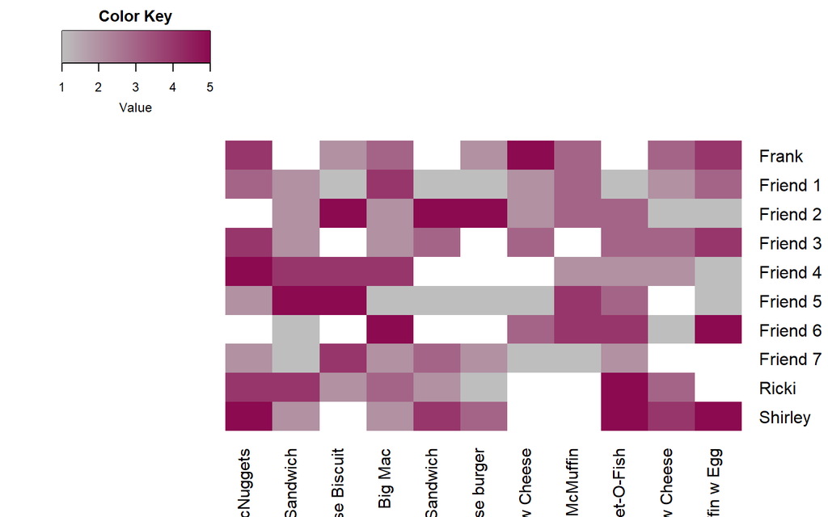

```r
data %>%
  spread(key = `Combo Meal`, value = Rating) %>%
  column_to_rownames('Customer') %>%
  as.matrix() %>%
  heatmap.2(trace = 'none',
            density.info = 'none',
            dendrogram = 'none',
            Rowv = FALSE,
            Colv = FALSE,
            col = colorRampPalette(c("grey", "deeppink4"))(n = 299))
```

# Separate Training Dataset & Test Dataset

The ratings of McDonald’s Combo Meal are then split into training dataset (85%) and test dataset (15%). In the `Train_Test_Split` table below, the training dataset is set to BLUE and the test dataset is set to RED under the `Data_Group` column.

```r
set.seed(3)
data_split <- data %>%
  mutate(Data_Group = sample.split(Rating, 0.85)) %>%
  mutate(Data_Group = if_else(Data_Group==TRUE, 'Train', 'Test'))

data_train <- data_split %>%
  filter(Data_Group == 'Train') %>%
  select(-Data_Group)

data_test <- data_split %>%
  filter(Data_Group == 'Test') %>%
  select(-Data_Group)

data_split %>%
  mutate(
  Data_Group = cell_spec(Data_Group, background = if_else(Data_Group == 'Test',
                                                    'lightpink','lightblue'))) %>%
  kable(escape = FALSE) %>%
  kable_styling(bootstrap_options = c("striped", "bordered"),
                full_width = FALSE,
                font_size = 12) %>%
  add_header_above(c('Train_Test_Split' = 4)) %>%
  scroll_box(width = "100%", height = "400px")
```

| Train_Test_Split Customer | Train_Test_Split Combo Meal | Train_Test_Split Rating | Train_Test_Split Data_Group |
| --- | --- | --- | --- |
| Ricki | Big Mac | 3 | Train |
| Ricki | Cheese burger | 1 | Test |
| Ricki | Quarter Pounder w Cheese | 3 | Test |
| Ricki | 10 Piece Chicken McNuggets | 4 | Test |
| Ricki | Filet-O-Fish | 5 | Train |
| Ricki | Artisan Grilled Chicken Sandwich | 4 | Train |
| Ricki | Buttermilk Crispy Chicken Sandwich | 2 | Train |
| Ricki | Bacon, Egg & Cheese Biscuit | 2 | Train |
| Shirley | Big Mac | 2 | Train |
| Shirley | Cheese burger | 3 | Train |
| Shirley | Quarter Pounder w Cheese | 4 | Train |
| Shirley | 10 Piece Chicken McNuggets | 5 | Test |
| Shirley | Filet-O-Fish | 5 | Train |
| Shirley | Artisan Grilled Chicken Sandwich | 2 | Train |
| Shirley | Buttermilk Crispy Chicken Sandwich | 4 | Train |
| Shirley | Sausage McMuffin w Egg | 5 | Test |
| Frank | Big Mac | 3 | Train |
| Frank | Cheese burger | 2 | Train |
| Frank | Quarter Pounder w Cheese | 3 | Train |
| Frank | Double Quarter Pounder w Cheese | 5 | Train |
| Frank | 10 Piece Chicken McNuggets | 4 | Train |
| Frank | Egg McMuffin | 3 | Train |
| Frank | Sausage McMuffin w Egg | 4 | Train |
| Frank | Bacon, Egg & Cheese Biscuit | 2 | Train |
| Friend 1 | Big Mac | 4 | Train |
| Friend 1 | Cheese burger | 1 | Train |
| Friend 1 | Quarter Pounder w Cheese | 2 | Train |
| Friend 1 | Double Quarter Pounder w Cheese | 2 | Test |
| Friend 1 | 10 Piece Chicken McNuggets | 3 | Train |
| Friend 1 | Filet-O-Fish | 1 | Train |

[output cut: 57 more lines]

# Create a User-Item Matrix

Reshaping the complete dataset from long format to wide format, with customers as users (in rows) and products as items (in columns). The training dataset and test dataset are separated by color with null values showing as ‘?’ in the table below.

```r
options(knitr.kable.NA = '?')
data_split %>%
  mutate(Rating = cell_spec(Rating,'html',
                            background  = if_else(Data_Group == 'Test','lightpink','lightblue'))) %>%
  select(-Data_Group) %>%
  spread(`Combo Meal`, Rating) %>%
  arrange(desc(Customer)) %>%
  kable(escape = FALSE, caption = 'User-Item Matrix', align = 'lccccccccccc') %>%
  kable_styling(bootstrap_options = c("striped", "bordered"),
                full_width = FALSE,
                font_size = 12) %>%
  add_header_above(c('User', 'Item' = 11)) %>%
  footnote(symbol = 'The numbers in BLUE are training set, and those in RED are test set')
```

User-Item Matrix

| User Customer | Item 10 Piece Chicken McNuggets | Item Artisan Grilled Chicken Sandwich | Item Bacon, Egg & Cheese Biscuit | Item Big Mac | Item Buttermilk Crispy Chicken Sandwich | Item Cheese burger | Item Double Quarter Pounder w Cheese | Item Egg McMuffin | Item Filet-O-Fish | Item Quarter Pounder w Cheese | Item Sausage McMuffin w Egg |
| --- | --- | --- | --- | --- | --- | --- | --- | --- | --- | --- | --- |
| Shirley | 5 | 2 | ? | 2 | 4 | 3 | ? | ? | 5 | 4 | 5 |
| Ricki | 4 | 4 | 2 | 3 | 2 | 1 | ? | ? | 5 | 3 | ? |
| Friend 7 | 2 | 1 | 4 | 2 | 3 | 2 | 1 | 1 | 2 | ? | ? |
| Friend 6 | ? | 1 | ? | 5 | ? | ? | 3 | 4 | 4 | 1 | 5 |
| Friend 5 | 2 | 5 | 5 | 1 | 1 | 1 | 1 | 4 | 3 | ? | 1 |
| Friend 4 | 5 | 4 | 4 | 4 | ? | ? | ? | 2 | 2 | 2 | 1 |
| Friend 3 | 4 | 2 | ? | 2 | 3 | ? | 3 | ? | 3 | 3 | 4 |
| Friend 2 | ? | 2 | 5 | 2 | 5 | 5 | 2 | 3 | 3 | 1 | 1 |
| Friend 1 | 3 | 2 | 1 | 4 | 1 | 1 | 2 | 3 | 1 | 2 | 3 |
| Frank | 4 | ? | 2 | 3 | ? | 2 | 5 | 3 | ? | 3 | 4 |

* The numbers in BLUE are training set, and those in RED are test set

# Calculate Raw Average Rating

Calculate the raw average rating for every user-item combination.

```r
mean_train_raw <- mean(data_train$Rating)

print(str_c('Raw average rating for every user-item combination: ', as.character(mean_train_raw)))
```

```
## [1] "Raw average rating for every user-item combination: 2.82432432432432"
```

# Calculate RMSE for Raw Average

Calculate RMSE for raw average rating for both of the training dataset and test dataset.

```r
RMSE_train_raw <- (data_train$Rating - mean_train_raw)^2 %>% mean() %>% sqrt()

print(str_c('RMSE of raw average rating for training set: ', as.character(RMSE_train_raw)))
```

```
## [1] "RMSE of raw average rating for training set: 1.34925513092493"
```

```r
RMSE_test_raw <- (data_test$Rating - mean_train_raw)^2 %>% mean() %>% sqrt()

print(str_c('RMSE of raw average rating for test set: ', as.character(RMSE_test_raw)))
```

```
## [1] "RMSE of raw average rating for test set: 1.3685239438972"
```

# Calculate the bias for each user and each item

Using the training dataset, we calculate the bias for each user and each item.

From the bias table below, it is observed that Friend 7 is the harshest customer, while the most popular product is the 10-Piece Chicken McNuggets Meal Combo.

```r
options(knitr.kable.NA = '')
user_bias_tb <- data_train %>%
  group_by(Customer) %>%
  summarise(User_Bias = mean(Rating) - mean_train_raw)


item_bias_tb <- data_train %>%
  group_by(`Combo Meal`) %>%
  summarise(Item_Bias = mean(Rating) - mean_train_raw)


user_bias_tb %>%
  arrange(desc(User_Bias)) %>%
  data.frame(row.names = NULL) %>%
  merge(item_bias_tb %>%
          arrange(desc(Item_Bias)) %>%
          data.frame(row.names = NULL), by = 0, all = TRUE) %>%
  arrange(desc(User_Bias)) %>%
  select(-Row.names) %>%
  kable(escape = FALSE, caption = 'Bias') %>%
  add_header_above(c('Bias for User' = 2, 'Bias for Item' = 2))
```

Bias

| Bias for User Customer | Bias for User User_Bias | Bias for Item Combo.Meal | Bias for Item Item_Bias |
| --- | --- | --- | --- |
| Shirley | 0.5090090 | 10 Piece Chicken McNuggets | 0.5090090 |
| Friend 4 | 0.4613900 | Bacon, Egg & Cheese Biscuit | 0.4613900 |
| Frank | 0.4256757 | Filet-O-Fish | 0.1756757 |
| Ricki | 0.3756757 | Sausage McMuffin w Egg | 0.1756757 |
| Friend 6 | 0.3423423 | Egg McMuffin | 0.0328185 |
| Friend 3 | 0.1756757 | Big Mac | -0.0243243 |
| Friend 2 | 0.0756757 | Cheese burger | -0.0743243 |
| Friend 5 | -0.3243243 | Buttermilk Crispy Chicken Sandwich | -0.1576577 |
| Friend 1 | -0.7132132 | Artisan Grilled Chicken Sandwich | -0.1993243 |
| Friend 7 | -0.8243243 | Double Quarter Pounder w Cheese | -0.3243243 |
|  |  | Quarter Pounder w Cheese | -0.5386100 |

# Calculate the Baseline Predictors

From the raw average rating, and the appropriate user and item biases, we calculate the baseline predictors for every user-item combination and present them by the table below.

```r
baseline_pred <- data.frame('Customer' = character(),
                            'Combo_Meal' = character(),
                            'Baseline_Predictor' = numeric(),
                            stringsAsFactors = FALSE)


for (user in data$Customer %>% unique()){
  for(item in data$`Combo Meal` %>% unique()){
    user_bias <- user_bias_tb$User_Bias[user_bias_tb$Customer == user]
    item_bias <- item_bias_tb$Item_Bias[item_bias_tb$`Combo Meal` == item]
    baseline_predictor <- pmax(pmin(mean_train_raw + user_bias + item_bias,5),1)

    baseline_pred <- add_row(baseline_pred,
                             Customer = user,
                             Combo_Meal = item,
                             Baseline_Predictor = baseline_predictor)
  }
}


baseline_pred %>%
  spread(key = 'Combo_Meal', value = 'Baseline_Predictor') %>%
  kable(caption = 'Baseline Predictors') %>%
  kable_styling(bootstrap_options = "striped",
                full_width = FALSE,
                font_size = 12) %>%
  add_header_above(c('User', 'Item' = 11))
```

Baseline Predictors

| User Customer | Item 10 Piece Chicken McNuggets | Item Artisan Grilled Chicken Sandwich | Item Bacon, Egg & Cheese Biscuit | Item Big Mac | Item Buttermilk Crispy Chicken Sandwich | Item Cheese burger | Item Double Quarter Pounder w Cheese | Item Egg McMuffin | Item Filet-O-Fish | Item Quarter Pounder w Cheese | Item Sausage McMuffin w Egg |
| --- | --- | --- | --- | --- | --- | --- | --- | --- | --- | --- | --- |
| Frank | 3.759009 | 3.050676 | 3.711390 | 3.225676 | 3.092342 | 3.175676 | 2.925676 | 3.282818 | 3.425676 | 2.711390 | 3.425676 |
| Friend 1 | 2.620120 | 1.911787 | 2.572501 | 2.086787 | 1.953453 | 2.036787 | 1.786787 | 2.143930 | 2.286787 | 1.572501 | 2.286787 |
| Friend 2 | 3.409009 | 2.700676 | 3.361390 | 2.875676 | 2.742342 | 2.825676 | 2.575676 | 2.932819 | 3.075676 | 2.361390 | 3.075676 |
| Friend 3 | 3.509009 | 2.800676 | 3.461390 | 2.975676 | 2.842342 | 2.925676 | 2.675676 | 3.032818 | 3.175676 | 2.461390 | 3.175676 |
| Friend 4 | 3.794723 | 3.086390 | 3.747104 | 3.261390 | 3.128057 | 3.211390 | 2.961390 | 3.318533 | 3.461390 | 2.747104 | 3.461390 |
| Friend 5 | 3.009009 | 2.300676 | 2.961390 | 2.475676 | 2.342342 | 2.425676 | 2.175676 | 2.532818 | 2.675676 | 1.961390 | 2.675676 |
| Friend 6 | 3.675676 | 2.967342 | 3.628057 | 3.142342 | 3.009009 | 3.092342 | 2.842342 | 3.199485 | 3.342342 | 2.628057 | 3.342342 |
| Friend 7 | 2.509009 | 1.800676 | 2.461390 | 1.975676 | 1.842342 | 1.925676 | 1.675676 | 2.032818 | 2.175676 | 1.461390 | 2.175676 |
| Ricki | 3.709009 | 3.000676 | 3.661390 | 3.175676 | 3.042342 | 3.125676 | 2.875676 | 3.232819 | 3.375676 | 2.661390 | 3.375676 |
| Shirley | 3.842342 | 3.134009 | 3.794723 | 3.309009 | 3.175676 | 3.259009 | 3.009009 | 3.366152 | 3.509009 | 2.794723 | 3.509009 |

# Calculate RMSE for Baseline Predictors

Finally, we calculate the RMSE for the baseline predictors for both of the training dataset and the test dataset.

```r
RMSE_train_baseline_pred <- data_train %>%
  left_join(baseline_pred, by = c('Customer' = 'Customer', 'Combo Meal' = 'Combo_Meal')) %>%
  rmse(Rating, Baseline_Predictor) %>%
  .$`.estimate`

print(str_c('RMSE of baseline predictor for training set: ', RMSE_train_baseline_pred))
```

```
## [1] "RMSE of baseline predictor for training set: 1.21011708247286"
```

```r
RMSE_test_baseline_pred <- data_test %>%
  left_join(baseline_pred, by = c('Customer' = 'Customer', 'Combo Meal' = 'Combo_Meal')) %>%
  rmse(Rating, Baseline_Predictor) %>%
  .$`.estimate`

print(str_c('RMSE of baseline predictor for test set: ', RMSE_test_baseline_pred))
```

```
## [1] "RMSE of baseline predictor for test set: 1.14332066988903"
```

# Summary

We have calculated the RMSE for raw average rating for our training dataset and test dataset earlier, and also the RMSE for the baseline predictors for both datasets. To compare the results, we can calculate the percentage increase/decrease of the two RMSE for the training and test datasets respectively.

From the results below, we can see that the RMSE for the training dataset is decreased by 10.31%, and that for the test dataset is decreased by 16.46% by using the baseline predictors instead of the raw average ratings.

Therefore, the performances of the RMSE for the baseline predictors are better.

```r
data.frame(Metrics = c('RMSE_Train_Raw',
                       'RMSE_Train_Baseline_Pred',
                       '% Change in RMSE of training set',
                       'RMSE_Test_Raw',
                       'RMSE_Test_Baseline_Pred',
                       '% Change in RMSE of Test Set'),
Value = c(RMSE_train_raw,
          RMSE_train_baseline_pred,
          (RMSE_train_baseline_pred - RMSE_train_raw)/RMSE_train_raw,
          RMSE_test_raw,
          RMSE_test_baseline_pred,
          (RMSE_test_baseline_pred - RMSE_test_raw)/RMSE_test_raw),
stringsAsFactors = FALSE) %>%
  mutate(Value = case_when(str_detect(Metrics, '%') ~ cell_spec(str_c(as.character(round(Value*100,2)),'%'), bold = TRUE),
                           TRUE ~ if_else(str_detect(Metrics,'Train'),
                                          color_bar('lightblue')(Value),
                                          color_bar('lightpink')(Value))),
         Metrics = case_when(str_detect(Metrics, '%') ~ cell_spec(Metrics, bold = TRUE),
                             TRUE ~ Metrics)) %>%
  kable(escape = FALSE, caption = 'Summary',align = 'lr') %>%
  kable_styling('hover') %>%
  row_spec(c(1,2,4,5), background = 'white') %>%
  row_spec(c(3,6), background = 'lightgrey')
```

Summary

| Metrics | Value |
| --- | --- |
| RMSE_Train_Raw | 1.3492551 |
| RMSE_Train_Baseline_Pred | 1.2101171 |
| % Change in RMSE of training set | -10.31% |
| RMSE_Test_Raw | 1.3685239 |
| RMSE_Test_Baseline_Pred | 1.1433207 |
| % Change in RMSE of Test Set | -16.46% |